# Risk Factor Analysis

## Outcome Variable

**Outcome Variable:** sstunted

## Predictor Variables

**Intervention Variable:** nchldlt5

**Adjustment Set:**

unadjusted

## Stratifying Variables

The analysis was stratified on these variable(s):

- agecat
- studyid
- country

## Data Summary

| agecat | studyid | country | nchldlt5 | sstunted | n_cell | n |
| --- | --- | --- | --- | --- | --- | --- |
| Birth | IRC | INDIA | 1 | 0 | 79 | 388 |
| Birth | IRC | INDIA | 1 | 1 | 5 | 388 |
| Birth | IRC | INDIA | 2+ | 0 | 293 | 388 |
| Birth | IRC | INDIA | 2+ | 1 | 11 | 388 |
| Birth | JiVitA-3 | BANGLADESH | 1 | 0 | 12217 | 22431 |
| Birth | JiVitA-3 | BANGLADESH | 1 | 1 | 1769 | 22431 |
| Birth | JiVitA-3 | BANGLADESH | 2+ | 0 | 7766 | 22431 |
| Birth | JiVitA-3 | BANGLADESH | 2+ | 1 | 679 | 22431 |
| Birth | NIH-Crypto | BANGLADESH | 1 | 0 | 515 | 732 |
| Birth | NIH-Crypto | BANGLADESH | 1 | 1 | 7 | 732 |
| Birth | NIH-Crypto | BANGLADESH | 2+ | 0 | 207 | 732 |
| Birth | NIH-Crypto | BANGLADESH | 2+ | 1 | 3 | 732 |
| Birth | PROVIDE | BANGLADESH | 1 | 0 | 388 | 539 |
| Birth | PROVIDE | BANGLADESH | 1 | 1 | 3 | 539 |
| Birth | PROVIDE | BANGLADESH | 2+ | 0 | 147 | 539 |
| Birth | PROVIDE | BANGLADESH | 2+ | 1 | 1 | 539 |
| 6 months | IRC | INDIA | 1 | 0 | 78 | 407 |
| 6 months | IRC | INDIA | 1 | 1 | 11 | 407 |
| 6 months | IRC | INDIA | 2+ | 0 | 300 | 407 |
| 6 months | IRC | INDIA | 2+ | 1 | 18 | 407 |
| 6 months | JiVitA-3 | BANGLADESH | 1 | 0 | 10177 | 16800 |
| 6 months | JiVitA-3 | BANGLADESH | 1 | 1 | 710 | 16800 |
| 6 months | JiVitA-3 | BANGLADESH | 2+ | 0 | 5604 | 16800 |
| 6 months | JiVitA-3 | BANGLADESH | 2+ | 1 | 309 | 16800 |
| 6 months | LCNI-5 | MALAWI | 1 | 0 | 362 | 811 |
| 6 months | LCNI-5 | MALAWI | 1 | 1 | 28 | 811 |
| 6 months | LCNI-5 | MALAWI | 2+ | 0 | 384 | 811 |
| 6 months | LCNI-5 | MALAWI | 2+ | 1 | 37 | 811 |
| 6 months | NIH-Crypto | BANGLADESH | 1 | 0 | 492 | 715 |
| 6 months | NIH-Crypto | BANGLADESH | 1 | 1 | 15 | 715 |
| 6 months | NIH-Crypto | BANGLADESH | 2+ | 0 | 200 | 715 |
| 6 months | NIH-Crypto | BANGLADESH | 2+ | 1 | 8 | 715 |
| 6 months | PROVIDE | BANGLADESH | 1 | 0 | 428 | 604 |
| 6 months | PROVIDE | BANGLADESH | 1 | 1 | 10 | 604 |
| 6 months | PROVIDE | BANGLADESH | 2+ | 0 | 162 | 604 |
| 6 months | PROVIDE | BANGLADESH | 2+ | 1 | 4 | 604 |
| 6 months | TanzaniaChild2 | TANZANIA, UNITED REPUBLIC OF | 1 | 0 | 1384 | 2020 |
| 6 months | TanzaniaChild2 | TANZANIA, UNITED REPUBLIC OF | 1 | 1 | 7 | 2020 |
| 6 months | TanzaniaChild2 | TANZANIA, UNITED REPUBLIC OF | 2+ | 0 | 617 | 2020 |
| 6 months | TanzaniaChild2 | TANZANIA, UNITED REPUBLIC OF | 2+ | 1 | 12 | 2020 |
| 24 months | IRC | INDIA | 1 | 0 | 82 | 409 |
| 24 months | IRC | INDIA | 1 | 1 | 7 | 409 |
| 24 months | IRC | INDIA | 2+ | 0 | 286 | 409 |
| 24 months | IRC | INDIA | 2+ | 1 | 34 | 409 |
| 24 months | JiVitA-3 | BANGLADESH | 1 | 0 | 4671 | 8622 |
| 24 months | JiVitA-3 | BANGLADESH | 1 | 1 | 783 | 8622 |
| 24 months | JiVitA-3 | BANGLADESH | 2+ | 0 | 2607 | 8622 |
| 24 months | JiVitA-3 | BANGLADESH | 2+ | 1 | 561 | 8622 |
| 24 months | LCNI-5 | MALAWI | 1 | 0 | 255 | 571 |
| 24 months | LCNI-5 | MALAWI | 1 | 1 | 28 | 571 |
| 24 months | LCNI-5 | MALAWI | 2+ | 0 | 247 | 571 |
| 24 months | LCNI-5 | MALAWI | 2+ | 1 | 41 | 571 |
| 24 months | NIH-Crypto | BANGLADESH | 1 | 0 | 336 | 514 |
| 24 months | NIH-Crypto | BANGLADESH | 1 | 1 | 21 | 514 |
| 24 months | NIH-Crypto | BANGLADESH | 2+ | 0 | 142 | 514 |
| 24 months | NIH-Crypto | BANGLADESH | 2+ | 1 | 15 | 514 |
| 24 months | PROVIDE | BANGLADESH | 1 | 0 | 389 | 578 |
| 24 months | PROVIDE | BANGLADESH | 1 | 1 | 35 | 578 |
| 24 months | PROVIDE | BANGLADESH | 2+ | 0 | 137 | 578 |
| 24 months | PROVIDE | BANGLADESH | 2+ | 1 | 17 | 578 |
| 24 months | TanzaniaChild2 | TANZANIA, UNITED REPUBLIC OF | 1 | 0 | 4 | 6 |
| 24 months | TanzaniaChild2 | TANZANIA, UNITED REPUBLIC OF | 1 | 1 | 1 | 6 |
| 24 months | TanzaniaChild2 | TANZANIA, UNITED REPUBLIC OF | 2+ | 0 | 1 | 6 |
| 24 months | TanzaniaChild2 | TANZANIA, UNITED REPUBLIC OF | 2+ | 1 | 0 | 6 |

The following strata were considered:

- agecat: 24 months, studyid: IRC, country: INDIA
- agecat: 24 months, studyid: JiVitA-3, country: BANGLADESH
- agecat: 24 months, studyid: LCNI-5, country: MALAWI
- agecat: 24 months, studyid: NIH-Crypto, country: BANGLADESH
- agecat: 24 months, studyid: PROVIDE, country: BANGLADESH
- agecat: 24 months, studyid: TanzaniaChild2, country: TANZANIA, UNITED REPUBLIC OF
- agecat: 6 months, studyid: IRC, country: INDIA
- agecat: 6 months, studyid: JiVitA-3, country: BANGLADESH
- agecat: 6 months, studyid: LCNI-5, country: MALAWI
- agecat: 6 months, studyid: NIH-Crypto, country: BANGLADESH
- agecat: 6 months, studyid: PROVIDE, country: BANGLADESH
- agecat: 6 months, studyid: TanzaniaChild2, country: TANZANIA, UNITED REPUBLIC OF
- agecat: Birth, studyid: IRC, country: INDIA
- agecat: Birth, studyid: JiVitA-3, country: BANGLADESH
- agecat: Birth, studyid: NIH-Crypto, country: BANGLADESH
- agecat: Birth, studyid: PROVIDE, country: BANGLADESH

### Dropped Strata

Some strata were dropped due to rare outcomes:

- agecat: Birth, studyid: NIH-Crypto, country: BANGLADESH
- agecat: Birth, studyid: PROVIDE, country: BANGLADESH
- agecat: 6 months, studyid: PROVIDE, country: BANGLADESH
- agecat: 24 months, studyid: TanzaniaChild2, country: TANZANIA, UNITED REPUBLIC OF

## Methods Detail

We’re interested in the causal parameters $E[Y_a]$ for all values of $a \in \mathcal{A}$. These parameters represent the mean outcome if, possibly contrary to fact, we intervened to set all units to have $A=a$. Under the randomization and positivity assumptions, these are identified by the statistical parameters $\psi_a=E_W[E_{Y|A,W}(Y|A=a,W)]$. In addition, we’re interested in the mean of $Y$, $E[Y]$ under no intervention (the observed mean). We will estimate these parameters by using SuperLearner to fit the relevant likelihood factors – $E_{Y|A,W}(Y|A=a,W)$ and $p(A=a|W)$, and then updating our likelihood fit using a joint TMLE.

For unadjusted analyses ($W=\{\}$), initial likelihoods were estimated using Lrnr_glm to estimate the simple $E(Y|A)$ and Lrnr_mean to estimate $p(A)$. For adjusted analyses, a small library containing Lrnr_glmnet, Lrnr_xgboost, and Lrnr_mean was used.

Having estimated these parameters, we will then use the delta method to estimate relative risks and attributable risks relative to a prespecified baseline level of $A$.

# Results Detail

## Results Plots

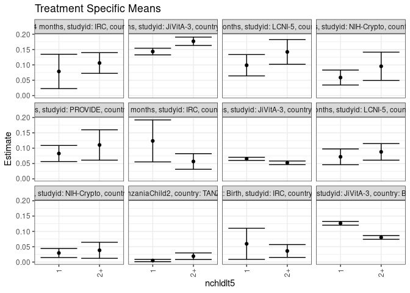

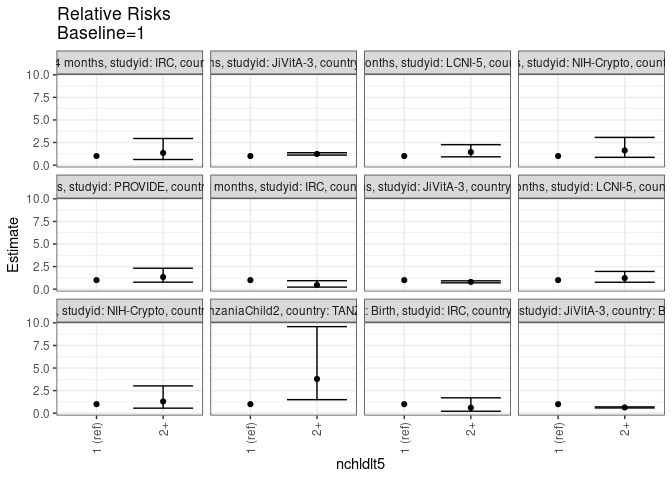

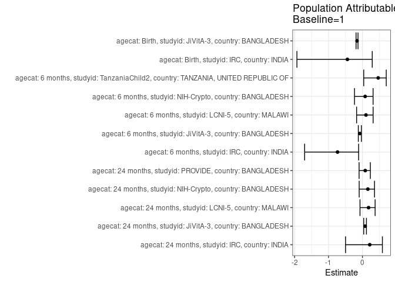

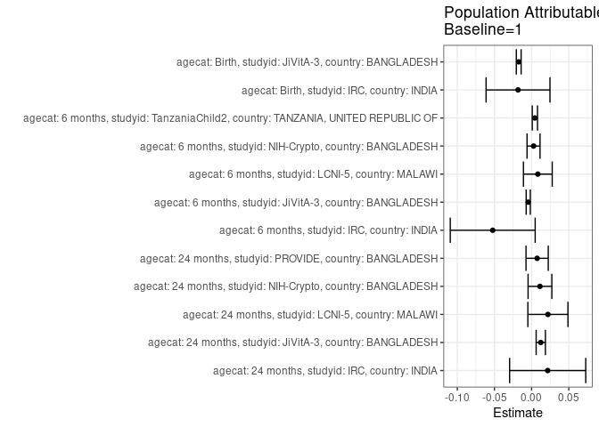

## Results Table

### Parameter: TSM

| agecat | studyid | country | intervention_level | baseline_level | estimate | ci_lower | ci_upper |
| --- | --- | --- | --- | --- | --- | --- | --- |
| Birth | IRC | INDIA | 1 | NA | 0.0595238 | 0.0088611 | 0.1101865 |
| Birth | IRC | INDIA | 2+ | NA | 0.0361842 | 0.0151644 | 0.0572040 |
| Birth | JiVitA-3 | BANGLADESH | 1 | NA | 0.1264836 | 0.1203245 | 0.1326428 |
| Birth | JiVitA-3 | BANGLADESH | 2+ | NA | 0.0804026 | 0.0742525 | 0.0865527 |
| 6 months | IRC | INDIA | 1 | NA | 0.1235955 | 0.0551349 | 0.1920561 |
| 6 months | IRC | INDIA | 2+ | NA | 0.0566038 | 0.0311742 | 0.0820333 |
| 6 months | JiVitA-3 | BANGLADESH | 1 | NA | 0.0652154 | 0.0601185 | 0.0703122 |
| 6 months | JiVitA-3 | BANGLADESH | 2+ | NA | 0.0522577 | 0.0463828 | 0.0581326 |
| 6 months | LCNI-5 | MALAWI | 1 | NA | 0.0717949 | 0.0461587 | 0.0974310 |
| 6 months | LCNI-5 | MALAWI | 2+ | NA | 0.0878860 | 0.0608240 | 0.1149480 |
| 6 months | NIH-Crypto | BANGLADESH | 1 | NA | 0.0295858 | 0.0148264 | 0.0443452 |
| 6 months | NIH-Crypto | BANGLADESH | 2+ | NA | 0.0384615 | 0.0123088 | 0.0646143 |
| 6 months | TanzaniaChild2 | TANZANIA, UNITED REPUBLIC OF | 1 | NA | 0.0050324 | 0.0013129 | 0.0087518 |
| 6 months | TanzaniaChild2 | TANZANIA, UNITED REPUBLIC OF | 2+ | NA | 0.0190779 | 0.0083846 | 0.0297712 |
| 24 months | IRC | INDIA | 1 | NA | 0.0786517 | 0.0226565 | 0.1346469 |
| 24 months | IRC | INDIA | 2+ | NA | 0.1062500 | 0.0724453 | 0.1400547 |
| 24 months | JiVitA-3 | BANGLADESH | 1 | NA | 0.1435644 | 0.1327587 | 0.1543700 |
| 24 months | JiVitA-3 | BANGLADESH | 2+ | NA | 0.1770833 | 0.1634598 | 0.1907069 |
| 24 months | LCNI-5 | MALAWI | 1 | NA | 0.0989399 | 0.0641224 | 0.1337575 |
| 24 months | LCNI-5 | MALAWI | 2+ | NA | 0.1423611 | 0.1019705 | 0.1827517 |
| 24 months | NIH-Crypto | BANGLADESH | 1 | NA | 0.0588235 | 0.0343922 | 0.0832549 |
| 24 months | NIH-Crypto | BANGLADESH | 2+ | NA | 0.0955414 | 0.0495145 | 0.1415683 |
| 24 months | PROVIDE | BANGLADESH | 1 | NA | 0.0825472 | 0.0563301 | 0.1087642 |
| 24 months | PROVIDE | BANGLADESH | 2+ | NA | 0.1103896 | 0.0608528 | 0.1599264 |

### Parameter: E(Y)

| agecat | studyid | country | intervention_level | baseline_level | estimate | ci_lower | ci_upper |
| --- | --- | --- | --- | --- | --- | --- | --- |
| Birth | IRC | INDIA | NA | NA | 0.0412371 | 0.0214268 | 0.0610475 |
| Birth | JiVitA-3 | BANGLADESH | NA | NA | 0.1091347 | 0.1045757 | 0.1136937 |
| 6 months | IRC | INDIA | NA | NA | 0.0712531 | 0.0462303 | 0.0962759 |
| 6 months | JiVitA-3 | BANGLADESH | NA | NA | 0.0606548 | 0.0568002 | 0.0645093 |
| 6 months | LCNI-5 | MALAWI | NA | NA | 0.0801480 | 0.0614493 | 0.0988466 |
| 6 months | NIH-Crypto | BANGLADESH | NA | NA | 0.0321678 | 0.0192256 | 0.0451101 |
| 6 months | TanzaniaChild2 | TANZANIA, UNITED REPUBLIC OF | NA | NA | 0.0094059 | 0.0051955 | 0.0136164 |
| 24 months | IRC | INDIA | NA | NA | 0.1002445 | 0.0711031 | 0.1293859 |
| 24 months | JiVitA-3 | BANGLADESH | NA | NA | 0.1558803 | 0.1471449 | 0.1646158 |
| 24 months | LCNI-5 | MALAWI | NA | NA | 0.1208406 | 0.0940828 | 0.1475985 |
| 24 months | NIH-Crypto | BANGLADESH | NA | NA | 0.0700389 | 0.0479542 | 0.0921236 |
| 24 months | PROVIDE | BANGLADESH | NA | NA | 0.0899654 | 0.0666186 | 0.1133122 |

### Parameter: RR

| agecat | studyid | country | intervention_level | baseline_level | estimate | ci_lower | ci_upper |
| --- | --- | --- | --- | --- | --- | --- | --- |
| Birth | IRC | INDIA | 1 | 1 | 1.0000000 | 1.0000000 | 1.0000000 |
| Birth | IRC | INDIA | 2+ | 1 | 0.6078947 | 0.2169190 | 1.7035666 |
| Birth | JiVitA-3 | BANGLADESH | 1 | 1 | 1.0000000 | 1.0000000 | 1.0000000 |
| Birth | JiVitA-3 | BANGLADESH | 2+ | 1 | 0.6356760 | 0.5811707 | 0.6952931 |
| 6 months | IRC | INDIA | 1 | 1 | 1.0000000 | 1.0000000 | 1.0000000 |
| 6 months | IRC | INDIA | 2+ | 1 | 0.4579760 | 0.2244433 | 0.9344988 |
| 6 months | JiVitA-3 | BANGLADESH | 1 | 1 | 1.0000000 | 1.0000000 | 1.0000000 |
| 6 months | JiVitA-3 | BANGLADESH | 2+ | 1 | 0.8013098 | 0.6978789 | 0.9200701 |
| 6 months | LCNI-5 | MALAWI | 1 | 1 | 1.0000000 | 1.0000000 | 1.0000000 |
| 6 months | LCNI-5 | MALAWI | 2+ | 1 | 1.2241262 | 0.7639304 | 1.9615465 |
| 6 months | NIH-Crypto | BANGLADESH | 1 | 1 | 1.0000000 | 1.0000000 | 1.0000000 |
| 6 months | NIH-Crypto | BANGLADESH | 2+ | 1 | 1.3000000 | 0.5593501 | 3.0213633 |
| 6 months | TanzaniaChild2 | TANZANIA, UNITED REPUBLIC OF | 1 | 1 | 1.0000000 | 1.0000000 | 1.0000000 |
| 6 months | TanzaniaChild2 | TANZANIA, UNITED REPUBLIC OF | 2+ | 1 | 3.7910516 | 1.4993541 | 9.5855087 |
| 24 months | IRC | INDIA | 1 | 1 | 1.0000000 | 1.0000000 | 1.0000000 |
| 24 months | IRC | INDIA | 2+ | 1 | 1.3508929 | 0.6193830 | 2.9463377 |
| 24 months | JiVitA-3 | BANGLADESH | 1 | 1 | 1.0000000 | 1.0000000 | 1.0000000 |
| 24 months | JiVitA-3 | BANGLADESH | 2+ | 1 | 1.2334770 | 1.1107513 | 1.3697625 |
| 24 months | LCNI-5 | MALAWI | 1 | 1 | 1.0000000 | 1.0000000 | 1.0000000 |
| 24 months | LCNI-5 | MALAWI | 2+ | 1 | 1.4388641 | 0.9155963 | 2.2611820 |
| 24 months | NIH-Crypto | BANGLADESH | 1 | 1 | 1.0000000 | 1.0000000 | 1.0000000 |
| 24 months | NIH-Crypto | BANGLADESH | 2+ | 1 | 1.6242038 | 0.8598043 | 3.0681842 |
| 24 months | PROVIDE | BANGLADESH | 1 | 1 | 1.0000000 | 1.0000000 | 1.0000000 |
| 24 months | PROVIDE | BANGLADESH | 2+ | 1 | 1.3372913 | 0.7717307 | 2.3173214 |

### Parameter: PAR

| agecat | studyid | country | intervention_level | baseline_level | estimate | ci_lower | ci_upper |
| --- | --- | --- | --- | --- | --- | --- | --- |
| Birth | IRC | INDIA | 1 | NA | -0.0182867 | -0.0612727 | 0.0246993 |
| Birth | JiVitA-3 | BANGLADESH | 1 | NA | -0.0173489 | -0.0205835 | -0.0141144 |
| 6 months | IRC | INDIA | 1 | NA | -0.0523424 | -0.1094670 | 0.0047821 |
| 6 months | JiVitA-3 | BANGLADESH | 1 | NA | -0.0045606 | -0.0073319 | -0.0017894 |
| 6 months | LCNI-5 | MALAWI | 1 | NA | 0.0083531 | -0.0110057 | 0.0277119 |
| 6 months | NIH-Crypto | BANGLADESH | 1 | NA | 0.0025820 | -0.0061590 | 0.0113231 |
| 6 months | TanzaniaChild2 | TANZANIA, UNITED REPUBLIC OF | 1 | NA | 0.0043736 | 0.0008368 | 0.0079104 |
| 24 months | IRC | INDIA | 1 | NA | 0.0215928 | -0.0295941 | 0.0727798 |
| 24 months | JiVitA-3 | BANGLADESH | 1 | NA | 0.0123159 | 0.0060972 | 0.0185347 |
| 24 months | LCNI-5 | MALAWI | 1 | NA | 0.0219007 | -0.0050548 | 0.0488562 |
| 24 months | NIH-Crypto | BANGLADESH | 1 | NA | 0.0112154 | -0.0047684 | 0.0271991 |
| 24 months | PROVIDE | BANGLADESH | 1 | NA | 0.0074182 | -0.0075484 | 0.0223848 |

### Parameter: PAF

| agecat | studyid | country | intervention_level | baseline_level | estimate | ci_lower | ci_upper |
| --- | --- | --- | --- | --- | --- | --- | --- |
| Birth | IRC | INDIA | 1 | NA | -0.4434524 | -1.9325479 | 0.2895070 |
| Birth | JiVitA-3 | BANGLADESH | 1 | NA | -0.1589682 | -0.1881969 | -0.1304586 |
| 6 months | IRC | INDIA | 1 | NA | -0.7345990 | -1.7048847 | -0.1123704 |
| 6 months | JiVitA-3 | BANGLADESH | 1 | NA | -0.0751900 | -0.1213185 | -0.0309591 |
| 6 months | LCNI-5 | MALAWI | 1 | NA | 0.1042209 | -0.1716618 | 0.3151435 |
| 6 months | NIH-Crypto | BANGLADESH | 1 | NA | 0.0802676 | -0.2334419 | 0.3141892 |
| 6 months | TanzaniaChild2 | TANZANIA, UNITED REPUBLIC OF | 1 | NA | 0.4649816 | 0.0380762 | 0.7024248 |
| 24 months | IRC | INDIA | 1 | NA | 0.2154015 | -0.4980614 | 0.5890724 |
| 24 months | JiVitA-3 | BANGLADESH | 1 | NA | 0.0790090 | 0.0379071 | 0.1183550 |
| 24 months | LCNI-5 | MALAWI | 1 | NA | 0.1812362 | -0.0714841 | 0.3743499 |
| 24 months | NIH-Crypto | BANGLADESH | 1 | NA | 0.1601307 | -0.0956435 | 0.3561953 |
| 24 months | PROVIDE | BANGLADESH | 1 | NA | 0.0824565 | -0.0985842 | 0.2336626 |